# Study 2: Point duration in homesigners and their hearing mothers

Bayesian duration models

The data are the index-finger points that Kita, Brentari and Goldin-Meadow (2025) identified in two sessions of four homesigning children and their hearing mothers. Kita et al. timed the stroke of each point. Each point was re-coded so that the annotation runs from the onset of the stroke to the release of the hold, giving three measures per point: the stroke, the hold (the re-coded point minus the stroke) and the whole point.

```r
source("../R/helpers.R")
suppressPackageStartupMessages({
  library(ggplot2)
  library(knitr)
  library(bayestestR)
})
```

# 1 Data

```r
raw <- read.csv("data/kita_points_duration_recoded.csv",
                check.names = FALSE, stringsAsFactors = FALSE)
stopifnot(nrow(raw) == 1123)

d_all <- raw %>%
  rename(total_ms = `stroke+hold_ms`) %>%
  mutate(person      = factor(person, levels = c("Child", "Mom")),
         person_lab  = factor(if_else(person == "Child", "Homesigning children", "Mothers"),
                              levels = c("Homesigning children", "Mothers")),
         family      = factor(subject),
         participant = factor(paste(subject, person, sep = "_")),
         session_id  = factor(paste(subject, session, sep = ".")),
         stroke_sec  = stroke_ms / 1000,
         total_sec   = total_ms / 1000,
         hold_sec    = hold_ms / 1000,
         log_stroke  = log(stroke_sec),
         log_total   = log(total_sec),
         hold_prop   = hold_ms / total_ms,
         floored     = hold_raw_ms < 0,
         age_months  = as.numeric(age_at_session_months))
```

Table S5: points coded, by session.

```r
d_all %>% count(session = as.character(session_id), person) %>%
  pivot_wider(names_from = person, values_from = n) %>%
  bind_rows(summarise(., session = "Total", Child = sum(Child), Mom = sum(Mom))) %>%
  kable()
```

| session | Child | Mom |
| --- | --- | --- |
| UCHS003.s0009 | 88 | 43 |
| UCHS003.s0011 | 77 | 87 |
| UCHS008.s0009 | 122 | 46 |
| UCHS008.s0010 | 64 | 80 |
| UCHS009.s0004 | 41 | 28 |
| UCHS009.s0006 | 110 | 24 |
| UCHS010.s0005 | 68 | 54 |
| UCHS010.s0006 | 90 | 101 |
| Total | 660 | 463 |

A point made with both hands was coded once for each hand. Annotations that share a point identifier and overlap in time are treated as one point, and the longer annotation is kept. Annotations that share an identifier but do not overlap are separate points.

```r
d_all <- d_all %>%
  group_by(subject, session, kita_id) %>%
  mutate(event_n  = n(),
         overlaps = event_n > 1 & max(eaf_onset_ms) < min(eaf_offset_ms),
         event_id = paste(subject, session, kita_id,
                          if_else(overlaps, "E", as.character(row_number())), sep = "_")) %>%
  ungroup()
dat <- d_all %>% group_by(event_id) %>%
  slice_max(total_ms, n = 1, with_ties = FALSE) %>% ungroup()

# Whether a point was produced alone or with other gestures, from the
# utterance coding (available for all but two points).
combo <- dat %>%
  filter(gm_accompanied %in% c("TRUE", "FALSE")) %>%
  mutate(alone = factor(if_else(gm_accompanied == "TRUE", "In combination", "Alone"),
                        levels = c("In combination", "Alone")),
         accompanied = as.integer(gm_accompanied == "TRUE"),
         n_companions = as.numeric(gm_n_companions))

# Handshape at the end of the stroke, coded crisp or sloppy by Kita et al.
crisp <- dat %>%
  filter(sloppiness_offset %in% c("crisp", "sloppy")) %>%
  mutate(crispness = factor(sloppiness_offset, levels = c("sloppy", "crisp")))

# One row per point and phase, for the model of stroke and hold together.
phase_dat <- dat %>%
  select(event_id, participant, session_id, person, person_lab, family, stroke_sec, hold_sec) %>%
  pivot_longer(c(stroke_sec, hold_sec), names_to = "phase", values_to = "dur_sec") %>%
  mutate(phase = factor(if_else(phase == "stroke_sec", "Stroke", "Hold"),
                        levels = c("Stroke", "Hold")))

stopifnot(all(dat$stroke_sec > 0), all(dat$total_sec > 0), all(dat$hold_sec >= 0),
          all(dat$stroke_ms + dat$hold_ms == dat$total_ms | dat$floored),
          all(dat$hold_ms[dat$floored] == 0))

dat %>% group_by(person_lab) %>%
  summarise(points = n(), stroke_s = mean(stroke_sec), hold_s = mean(hold_sec),
            whole_s = mean(total_sec), no_hold = sum(hold_sec == 0),
            hold_set_to_zero = sum(floored), .groups = "drop") %>%
  kable(digits = 2, caption = "Points analyzed (arithmetic means in seconds)")
```

Points analyzed (arithmetic means in seconds)

| person_lab | points | stroke_s | hold_s | whole_s | no_hold | hold_set_to_zero |
| --- | --- | --- | --- | --- | --- | --- |
| Homesigning children | 655 | 0.37 | 0.57 | 0.92 | 108 | 24 |
| Mothers | 462 | 0.34 | 0.91 | 1.25 | 41 | 6 |

```r
c(points = nrow(dat), context_coded = nrow(combo), alone = sum(combo$alone == "Alone"),
  hold_zero = sum(dat$hold_sec == 0), hold_set_to_zero = sum(dat$floored))
```

```
##           points    context_coded            alone        hold_zero
##             1117             1115              417              149
## hold_set_to_zero
##               30
```

# 2 Priors

As in Study 1, except that the intercept is Normal(-1, 1), which places 95% of the prior mass on geometric means between about 0.05 s and 2.7 s. For the hurdle part of the hold models (the probability that a point has no hold): intercept Normal(0, 1.5), effects Normal(0, 1).

```r
std_priors <- c(prior(normal(-1, 1), class = Intercept),
                prior(normal(0, 0.5), class = b),
                prior(exponential(1), class = sd),
                prior(exponential(1), class = sigma))
hurdle_priors <- c(std_priors,
                   prior(normal(0, 1.5), class = Intercept, dpar = "hu"),
                   prior(normal(0, 1), class = b, dpar = "hu"))

ADAPT <- 0.99
fit <- function(name, formula, data, prior = std_priors, family = gaussian(), adapt = ADAPT, ...)
  fit_or_load(name, formula, data, prior, family, adapt_delta = adapt, ...)

# Child is the reference level, so b_personMom is the mother - child contrast.
draws_of <- function(m, par) as_draws_df(m)[[par]]
geo_means <- function(m, b = "b_personMom", int = "b_Intercept", inv = exp) {
  d <- as_draws_df(m)
  bind_rows(summ(inv(d[[int]]), "Children"), summ(inv(d[[int]] + d[[b]]), "Mothers")) %>%
    select(term, estimate, lower, upper)
}
share_within <- function(x, w) mean(abs(x) < w)
```

Every model has random intercepts for participant (eight: four children and four mothers) and session (eight). Each session is shared by a child and their mother, so the child-mother comparison is made within session.

```r
m_prior <- fit("prior_only_total",
               bf(log_total ~ person + (1 | participant) + (1 | session_id)),
               dat, sample_prior = "only")
round(quantile(exp(posterior_predict(m_prior, ndraws = 400)), c(0.025, 0.5, 0.975)), 3)
```

```
##   2.5%    50%  97.5%
##  0.002  0.346 77.081
```

# 3 Whole point

```r
m_total <- fit("total_person",
               bf(log_total ~ person + (1 | participant) + (1 | session_id)), dat)
kable(convergence(m_total, "Whole point"), digits = 3)
```

| model | N | max_rhat | bulk_ess_fixed | bulk_ess_all | tail_ess_all | divergences |
| --- | --- | --- | --- | --- | --- | --- |
| Whole point | 1117 | 1.002 | 2569.771 | 1776.262 | 2097.057 | 1 |

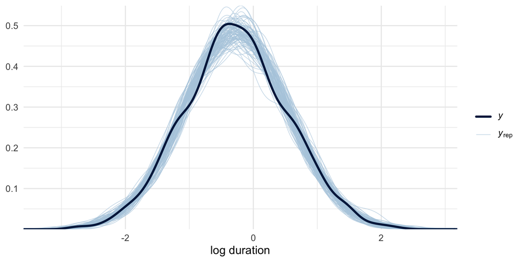

```r
pp_check(m_total, ndraws = 100) + labs(x = "log duration") + theme_minimal()
```

```r
kable(geo_means(m_total), digits = 2, caption = "Geometric mean duration (s)")
```

Geometric mean duration (s)

| term | estimate | lower | upper |
| --- | --- | --- | --- |
| Children | 0.67 | 0.58 | 0.77 |
| Mothers | 0.90 | 0.77 | 1.04 |

```r
whole <- draws_of(m_total, "b_personMom")
kable(summ(whole, "Mother - child (log-seconds)"), digits = 3)
```

| term | estimate | lower | upper | p_positive |
| --- | --- | --- | --- | --- |
| Mother - child (log-seconds) | 0.291 | 0.153 | 0.408 | 0.993 |

# 4 Stroke

```r
m_stroke <- fit("stroke_person",
                bf(log_stroke ~ person + (1 | participant) + (1 | session_id)), dat)
kable(convergence(m_stroke, "Stroke"), digits = 3)
```

| model | N | max_rhat | bulk_ess_fixed | bulk_ess_all | tail_ess_all | divergences |
| --- | --- | --- | --- | --- | --- | --- |
| Stroke | 1117 | 1.003 | 4102.938 | 1837.926 | 2443.496 | 0 |

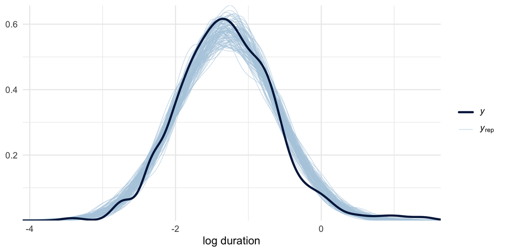

```r
pp_check(m_stroke, ndraws = 100) + labs(x = "log duration") + theme_minimal()
```

```r
kable(geo_means(m_stroke), digits = 2, caption = "Geometric mean duration (s)")
```

Geometric mean duration (s)

| term | estimate | lower | upper |
| --- | --- | --- | --- |
| Children | 0.27 | 0.24 | 0.31 |
| Mothers | 0.29 | 0.26 | 0.33 |

```r
stroke <- draws_of(m_stroke, "b_personMom")
kable(summ(stroke, "Mother - child (log-seconds)"), digits = 3)
```

| term | estimate | lower | upper | p_positive |
| --- | --- | --- | --- | --- |
| Mother - child (log-seconds) | 0.054 | -0.078 | 0.194 | 0.77 |

```r
# The 95% highest-density interval lies inside neither region of practical equivalence
c(within_0.10 = share_within(stroke, 0.10), within_0.20 = share_within(stroke, 0.20),
  p_difference_over_20_percent = mean(abs(stroke) > log(1.2)),
  whole_point_within_0.10 = share_within(whole, 0.10))
```

```
##                  within_0.10                  within_0.20
##                       0.6955                       0.9410
## p_difference_over_20_percent      whole_point_within_0.10
##                       0.0780                       0.0240
```

```r
hdi(stroke, ci = 0.95)
```

```
## 95% HDI: [-0.13, 0.24]
```

# 5 Hold

The hold is zero for some points, so it is modeled with a hurdle log-normal likelihood, which estimates separately the probability that a point has no hold and the length of the hold when there is one.

```r
m_hold <- fit("hold_person",
              bf(hold_sec ~ person + (1 | participant) + (1 | session_id),
                 hu ~ person + (1 | participant)),
              dat, prior = hurdle_priors, family = hurdle_lognormal())
kable(convergence(m_hold, "Hold"), digits = 3)
```

| model | N | max_rhat | bulk_ess_fixed | bulk_ess_all | tail_ess_all | divergences |
| --- | --- | --- | --- | --- | --- | --- |
| Hold | 1117 | 1.003 | 3365.945 | 1508.096 | 2834.309 | 0 |

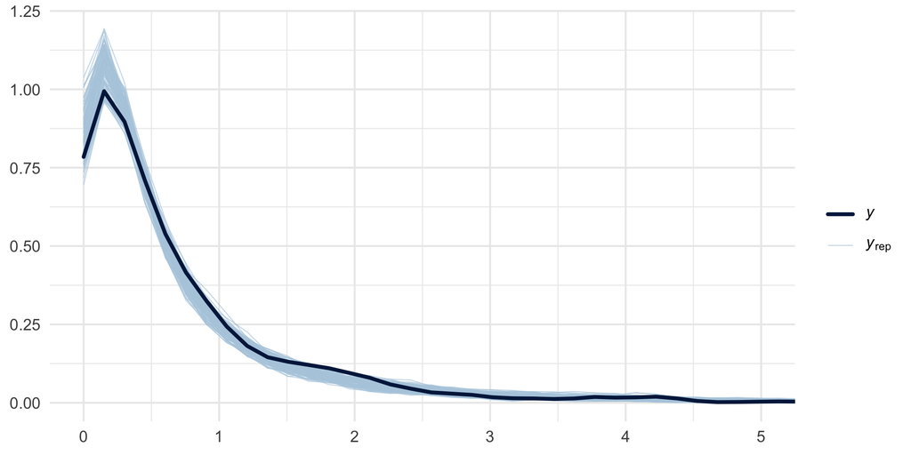

```r
pp_check(m_hold, ndraws = 100) + coord_cartesian(xlim = c(0, 5)) + theme_minimal()
```

```r
kable(geo_means(m_hold), digits = 2, caption = "Hold length when there is a hold (s)")
```

Hold length when there is a hold (s)

| term | estimate | lower | upper |
| --- | --- | --- | --- |
| Children | 0.39 | 0.31 | 0.49 |
| Mothers | 0.57 | 0.44 | 0.71 |

```r
kable(summ(draws_of(m_hold, "b_personMom"), "Mother - child (log-seconds)"), digits = 3)
```

| term | estimate | lower | upper | p_positive |
| --- | --- | --- | --- | --- |
| Mother - child (log-seconds) | 0.375 | 0.1 | 0.592 | 0.977 |

```r
m_hold_nf <- fit("hold_nofloor",
                 bf(hold_sec ~ person + (1 | participant) + (1 | session_id),
                    hu ~ person + (1 | participant)),
                 filter(dat, !floored), prior = hurdle_priors, family = hurdle_lognormal())
kable(geo_means(m_hold_nf, b = "b_hu_personMom", int = "b_hu_Intercept", inv = plogis),
      digits = 2, caption = "Probability that a point has no hold (without the 30 points set to zero)")
```

Probability that a point has no hold (without the 30 points set to zero)

| term | estimate | lower | upper |
| --- | --- | --- | --- |
| Children | 0.13 | 0.04 | 0.30 |
| Mothers | 0.12 | 0.03 | 0.28 |

```r
bind_rows(summ(draws_of(m_hold, "b_hu_personMom"), "All points"),
          summ(draws_of(m_hold_nf, "b_hu_personMom"), "Without the 30 points set to zero")) %>%
  kable(digits = 3, caption = "Mother - child difference in P(no hold), log-odds")
```

Mother - child difference in P(no hold), log-odds

| term | estimate | lower | upper | p_positive |
| --- | --- | --- | --- | --- |
| All points | -0.514 | -1.347 | 0.380 | 0.161 |
| Without the 30 points set to zero | -0.151 | -1.390 | 1.086 | 0.417 |

# 6 Stroke and hold together

One model of both phases of every point. The phase-by-person interaction is the difference between the mother - child contrast in the hold and in the stroke. A point-level intercept pairs the two phases of each point; random phase slopes for participant and session stop the interaction from being estimated as if it rested on 2,234 independent observations; and the residual standard deviation differs by phase. LKJ(2) prior on the random-effect correlations.

```r
phase_priors <- c(prior(normal(-1, 1), class = Intercept),
                  prior(normal(0, 0.5), class = b),
                  prior(exponential(1), class = sd),
                  prior(lkj(2), class = cor),
                  prior(normal(0, 1), class = Intercept, dpar = "sigma"),
                  prior(normal(0, 0.5), class = b, dpar = "sigma"),
                  prior(normal(0, 1.5), class = Intercept, dpar = "hu"),
                  prior(normal(0, 1), class = b, dpar = "hu"))
m_phase <- fit("phase_person_full",
               bf(dur_sec ~ phase * person + (1 + phase | participant) +
                    (1 + phase | session_id) + (1 | event_id),
                  hu ~ phase * person, sigma ~ phase),
               phase_dat, prior = phase_priors, family = hurdle_lognormal())

# Alternative specifications (Table S6B)
phase_pos <- phase_dat %>% filter(dur_sec > 0) %>% mutate(ld = log(dur_sec))
m_phase_pos <- fit("phase_positive",
                   bf(ld ~ phase * person + (1 + phase | participant) +
                        (1 + phase | session_id) + (1 | event_id), sigma ~ phase),
                   phase_pos,
                   prior = c(prior(normal(-1, 1), class = Intercept),
                             prior(normal(0, 0.5), class = b),
                             prior(exponential(1), class = sd),
                             prior(lkj(2), class = cor),
                             prior(normal(0, 1), class = Intercept, dpar = "sigma"),
                             prior(normal(0, 0.5), class = b, dpar = "sigma")))
m_phase_simple <- fit("phase_person",
                      bf(dur_sec ~ phase * person + (1 | event_id) + (1 | participant) +
                           (1 | session_id), hu ~ phase * person),
                      phase_dat, prior = hurdle_priors, family = hurdle_lognormal())

d <- as_draws_df(m_phase)
interaction <- d$`b_phaseHold:personMom`
bind_rows(summ(d$b_personMom, "Mother - child, stroke"),
          summ(d$b_personMom + interaction, "Mother - child, hold"),
          summ(interaction, "Interaction (primary model)"),
          summ(draws_of(m_phase_simple, "b_phaseHold:personMom"),
               "Interaction, no random slopes, one residual SD"),
          summ(draws_of(m_phase_pos, "b_phaseHold:personMom"),
               "Interaction, positive durations only")) %>%
  kable(digits = 3, caption = "Phase by person (log-seconds)")
```

Phase by person (log-seconds)

| term | estimate | lower | upper | p_positive |
| --- | --- | --- | --- | --- |
| Mother - child, stroke | 0.054 | -0.062 | 0.176 | 0.793 |
| Mother - child, hold | 0.382 | 0.080 | 0.645 | 0.972 |
| Interaction (primary model) | 0.329 | 0.012 | 0.608 | 0.950 |
| Interaction, no random slopes, one residual SD | 0.401 | 0.274 | 0.528 | 1.000 |
| Interaction, positive durations only | 0.334 | 0.026 | 0.613 | 0.955 |

```r
# A check that does not depend on the model: for each dyad and each session,
# the hold contrast minus the stroke contrast in mean log duration (holds
# longer than zero), tested against zero.
by_unit <- function(unit) dat %>% filter(hold_sec > 0) %>%
  group_by(.data[[unit]], person) %>%
  summarise(hold = mean(log(hold_sec)), stroke = mean(log_stroke), .groups = "drop") %>%
  pivot_wider(names_from = person, values_from = c(hold, stroke)) %>%
  mutate(contrast = (hold_Mom - hold_Child) - (stroke_Mom - stroke_Child))
for (unit in c("family", "session_id")) {
  x <- by_unit(unit); tt <- t.test(x$contrast)
  cat(sprintf("%s: mean %.3f, SD %.3f, t(%d) = %.2f, p = %.3f\n", unit,
              mean(x$contrast), sd(x$contrast), tt$parameter, tt$statistic, tt$p.value))
}
```

```
## family: mean 0.272, SD 0.342, t(3) = 1.60, p = 0.209
## session_id: mean 0.283, SD 0.331, t(7) = 2.41, p = 0.047
```

# 7 The child-mother contrast within each dyad

```r
m_dyad_total <- fit("perdyad_total",
                    bf(log_total ~ person * family + (1 | session_id)), dat)
m_dyad_stroke <- fit("perdyad_stroke",
                     bf(log_stroke ~ person * family + (1 | session_id)), dat)
m_dyad_hold <- fit("perdyad_hold",
                   bf(hold_sec ~ person * family + (1 | session_id), hu ~ person),
                   dat, prior = hurdle_priors, family = hurdle_lognormal())

per_dyad <- function(m, measure) {
  d <- as_draws_df(m); fams <- levels(dat$family)
  bind_rows(lapply(seq_along(fams), function(i) {
    x <- d$b_personMom
    if (i > 1) x <- x + d[[paste0("b_personMom:family", fams[i])]]
    summ(x, fams[i])
  })) %>% mutate(measure = measure)
}
dyads <- bind_rows(per_dyad(m_dyad_total, "Whole point"),
                   per_dyad(m_dyad_hold, "Hold"),
                   per_dyad(m_dyad_stroke, "Stroke"))
kable(dyads, digits = 3, caption = "Table S7: mother - child within each dyad (log-seconds)")
```

Table S7: mother - child within each dyad (log-seconds)

| term | estimate | lower | upper | p_positive | measure |
| --- | --- | --- | --- | --- | --- |
| UCHS003 | 0.311 | 0.172 | 0.454 | 1.000 | Whole point |
| UCHS008 | 0.278 | 0.133 | 0.427 | 0.999 | Whole point |
| UCHS009 | 0.204 | 0.001 | 0.402 | 0.946 | Whole point |
| UCHS010 | 0.352 | 0.213 | 0.488 | 1.000 | Whole point |
| UCHS003 | 0.443 | 0.256 | 0.632 | 1.000 | Hold |
| UCHS008 | 0.384 | 0.164 | 0.609 | 0.997 | Hold |
| UCHS009 | 0.146 | -0.156 | 0.452 | 0.780 | Hold |
| UCHS010 | 0.559 | 0.355 | 0.762 | 1.000 | Hold |
| UCHS003 | 0.047 | -0.074 | 0.169 | 0.732 | Stroke |
| UCHS008 | 0.090 | -0.035 | 0.215 | 0.877 | Stroke |
| UCHS009 | 0.239 | 0.072 | 0.409 | 0.990 | Stroke |
| UCHS010 | -0.103 | -0.222 | 0.013 | 0.078 | Stroke |

# 8 Points produced alone

```r
m_iso_total <- fit("iso_total",
                   bf(log_total ~ alone * person + (1 | participant) + (1 | session_id)), combo)
m_iso_stroke <- fit("iso_stroke",
                    bf(log_stroke ~ alone * person + (1 | participant) + (1 | session_id)), combo)

iso_effects <- function(m, measure) {
  d <- as_draws_df(m); ix <- d$`b_aloneAlone:personMom`
  bind_rows(summ(d$b_personMom, "Mother - child, with other gestures"),
            summ(d$b_personMom + ix, "Mother - child, alone"),
            summ(d$b_aloneAlone, "Alone - with other gestures, children"),
            summ(d$b_aloneAlone + ix, "Alone - with other gestures, mothers"),
            summ(ix, "Isolation by person interaction")) %>%
    mutate(measure = measure)
}
iso <- bind_rows(iso_effects(m_iso_total, "Whole point"), iso_effects(m_iso_stroke, "Stroke"))
kable(iso, digits = 3, caption = "Table S6C (log-seconds)")
```

Table S6C (log-seconds)

| term | estimate | lower | upper | p_positive | measure |
| --- | --- | --- | --- | --- | --- |
| Mother - child, with other gestures | 0.217 | 0.073 | 0.355 | 0.982 | Whole point |
| Mother - child, alone | 0.307 | 0.144 | 0.466 | 0.993 | Whole point |
| Alone - with other gestures, children | 0.134 | 0.026 | 0.242 | 0.978 | Whole point |
| Alone - with other gestures, mothers | 0.225 | 0.109 | 0.341 | 0.999 | Whole point |
| Isolation by person interaction | 0.090 | -0.065 | 0.248 | 0.822 | Whole point |
| Mother - child, with other gestures | 0.124 | -0.029 | 0.283 | 0.913 | Stroke |
| Mother - child, alone | -0.096 | -0.263 | 0.071 | 0.164 | Stroke |
| Alone - with other gestures, children | 0.188 | 0.098 | 0.279 | 1.000 | Stroke |
| Alone - with other gestures, mothers | -0.032 | -0.129 | 0.065 | 0.300 | Stroke |
| Isolation by person interaction | -0.220 | -0.355 | -0.088 | 0.002 | Stroke |

# 9 Handshape crispness

```r
table(crisp$person_lab, crisp$crispness)
```

```
##
##                        sloppy crisp
##   Homesigning children    102   472
##   Mothers                 117   327
```

```r
m_crisp_stroke <- fit("crisp_stroke",
                      bf(log_stroke ~ crispness * person + (1 | participant) + (1 | session_id)),
                      crisp)
m_crisp_hold <- fit("crisp_hold",
                    bf(hold_sec ~ crispness * person + (1 | participant) + (1 | session_id),
                       hu ~ crispness + person),
                    crisp, prior = hurdle_priors, family = hurdle_lognormal())
bind_rows(summ(draws_of(m_crisp_stroke, "b_crispnesscrisp"), "Stroke: crisp - sloppy, children"),
          summ(draws_of(m_crisp_stroke, "b_crispnesscrisp:personMom"), "Stroke: crispness by person"),
          summ(draws_of(m_crisp_hold, "b_crispnesscrisp"), "Hold length: crisp - sloppy, children"),
          summ(draws_of(m_crisp_hold, "b_crispnesscrisp:personMom"), "Hold length: crispness by person"),
          summ(draws_of(m_crisp_hold, "b_hu_crispnesscrisp"), "P(no hold): crisp - sloppy (log-odds)")) %>%
  kable(digits = 3, caption = "Table S6D")
```

Table S6D

| term | estimate | lower | upper | p_positive |
| --- | --- | --- | --- | --- |
| Stroke: crisp - sloppy, children | 0.101 | -0.014 | 0.215 | 0.920 |
| Stroke: crispness by person | 0.039 | -0.120 | 0.193 | 0.651 |
| Hold length: crisp - sloppy, children | -0.117 | -0.310 | 0.075 | 0.170 |
| Hold length: crispness by person | 0.011 | -0.249 | 0.273 | 0.528 |
| P(no hold): crisp - sloppy (log-odds) | -0.397 | -0.744 | -0.044 | 0.038 |

# 10 Alternative specifications of the whole-point model

Thirteen refits of the whole-point model, each changing one aspect of it (Table S8).

```r
f_total <- bf(log_total ~ person + (1 | participant) + (1 | session_id))

m_wide <- fit("total_person_wide", f_total, dat,
              prior = c(prior(normal(-1, 2), class = Intercept),
                        prior(normal(0, 1), class = b),
                        prior(exponential(1), class = sd),
                        prior(exponential(1), class = sigma)))
m_sd2 <- fit("total_person_narrowsd", f_total, dat,
             prior = c(prior(normal(-1, 1), class = Intercept),
                       prior(normal(0, 0.5), class = b),
                       prior(exponential(2), class = sd),
                       prior(exponential(1), class = sigma)))
# The family-level fits have four levels, so adapt_delta is raised.
m_family <- fit("total_person_family",
                bf(log_total ~ person + (1 | participant) + (1 | session_id) + (1 | family)),
                dat, adapt = 0.999)
m_family_slope <- fit("total_person_familyslope",
                      bf(log_total ~ person + (1 | participant) + (1 | session_id) +
                           (1 + person || family)),
                      dat, adapt = 0.999)
utterances <- dat %>% filter(!gm_utt_num %in% c("", NA)) %>%
  mutate(utt_id = factor(paste(session_id, person, gm_utt_num, sep = "_")))
m_utterance <- fit("total_person_utt",
                   bf(log_total ~ person + (1 | participant) + (1 | session_id) + (1 | utt_id)),
                   utterances)
m_gamma <- fit("total_gamma",
               bf(total_sec ~ person + (1 | participant) + (1 | session_id)), dat,
               prior = c(prior(normal(-1, 1), class = Intercept),
                         prior(normal(0, 0.5), class = b),
                         prior(exponential(1), class = sd),
                         prior(exponential(1), class = shape)),
               family = Gamma(link = "log"))
m_person_session <- fit("total_ps",
                        bf(log_total ~ person + (1 | participant) + (1 | session_id) + (1 | ps)),
                        mutate(dat, ps = interaction(participant, session_id, drop = TRUE)))
m_companions <- fit("total_ncomp",
                    bf(log_total ~ person + ncomp + (1 | participant) + (1 | session_id)),
                    combo %>% mutate(ncomp = as.numeric(gm_n_companions)) %>% filter(!is.na(ncomp)))
m_no_zero_holds <- refit_on("sub_no_floored_total", m_total, filter(dat, !floored))
m_without <- lapply(setNames(levels(dat$family), levels(dat$family)), function(f)
  refit_on(paste0("loso_", f, "_total"), m_total, filter(dat, family != f)))

alternatives <- c(
  list("Wider priors: intercept Normal(-1, 2), fixed effects Normal(0, 1)" = m_wide,
       "Random-effect SDs Exponential(2)" = m_sd2,
       "Added family intercept" = m_family,
       "Added person slope by family" = m_family_slope,
       "Added utterance intercept" = m_utterance,
       "Gamma likelihood" = m_gamma,
       "Added person-by-session intercept" = m_person_session,
       "Number of accompanying gestures as covariate" = m_companions,
       "Without the 30 points with hold set to zero" = m_no_zero_holds),
  setNames(m_without, paste("Without family", names(m_without))))

table_s8 <- bind_rows(
  summ(whole, "Primary model") %>% mutate(N = nobs(m_total)),
  bind_rows(Map(function(m, label) summ(draws_of(m, "b_personMom"), label) %>% mutate(N = nobs(m)),
                alternatives, names(alternatives))))
kable(select(table_s8, term, N, estimate, lower, upper, p_positive), digits = 3,
      caption = "Table S8: mother - child, whole point (log-seconds)")
```

Table S8: mother - child, whole point (log-seconds)

| term | N | estimate | lower | upper | p_positive |
| --- | --- | --- | --- | --- | --- |
| Primary model | 1117 | 0.291 | 0.153 | 0.408 | 0.993 |
| Wider priors: intercept Normal(-1, 2), fixed effects Normal(0, 1) | 1117 | 0.300 | 0.169 | 0.426 | 0.992 |
| Random-effect SDs Exponential(2) | 1117 | 0.292 | 0.162 | 0.405 | 0.994 |
| Added family intercept | 1117 | 0.295 | 0.184 | 0.401 | 0.998 |
| Added person slope by family | 1117 | 0.274 | 0.068 | 0.447 | 0.969 |
| Added utterance intercept | 1115 | 0.263 | 0.123 | 0.394 | 0.993 |
| Gamma likelihood | 1117 | 0.269 | 0.123 | 0.393 | 0.990 |
| Added person-by-session intercept | 1117 | 0.280 | 0.112 | 0.437 | 0.988 |
| Number of accompanying gestures as covariate | 1115 | 0.251 | 0.114 | 0.378 | 0.988 |
| Without the 30 points with hold set to zero | 1087 | 0.280 | 0.157 | 0.395 | 0.994 |
| Without family UCHS003 | 824 | 0.281 | 0.118 | 0.429 | 0.985 |
| Without family UCHS008 | 808 | 0.288 | 0.082 | 0.464 | 0.972 |
| Without family UCHS009 | 914 | 0.301 | 0.098 | 0.476 | 0.974 |
| Without family UCHS010 | 805 | 0.257 | 0.059 | 0.418 | 0.965 |

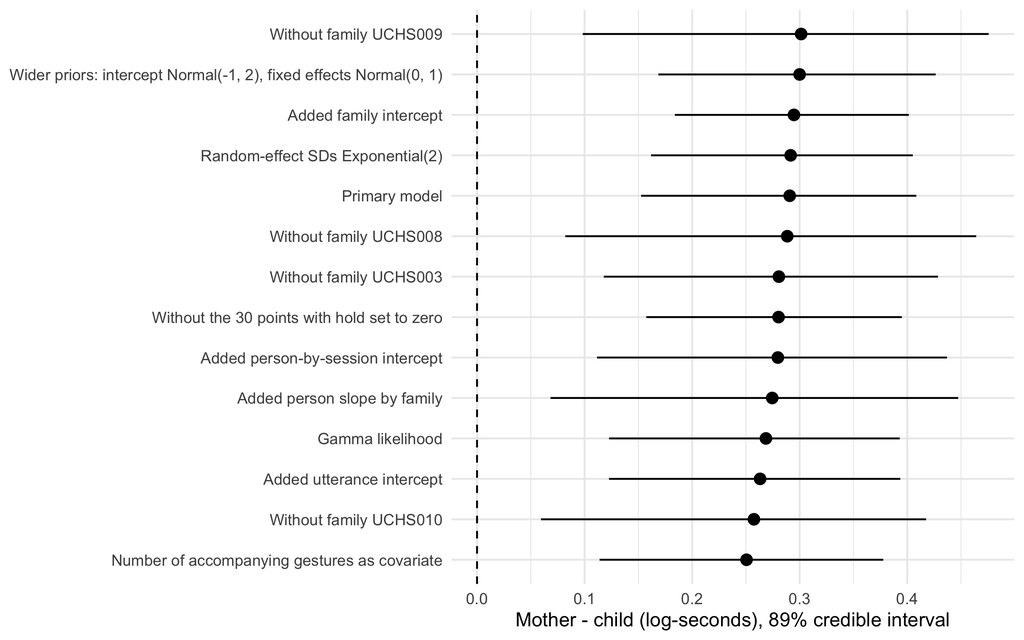

```r
ggplot(table_s8, aes(estimate, reorder(term, estimate))) +
  geom_vline(xintercept = 0, linetype = "dashed") +
  geom_pointrange(aes(xmin = lower, xmax = upper)) +
  labs(x = "Mother - child (log-seconds), 89% credible interval", y = NULL) +
  theme_minimal(base_size = 11)
```

# 11 Figure 4

Density of point durations for children and mothers: the whole point (top) and the stroke (bottom), for all points (left) and points produced alone (right). Dashed lines are arithmetic means.

```r
person_cols <- c("Homesigning children" = "#619CFF", "Mothers" = "#F8766D")
panel <- bind_rows(dat %>% mutate(set = "All points"),
                   combo %>% filter(alone == "Alone") %>% mutate(set = "Isolated points only")) %>%
  mutate(Stroke = stroke_sec, `Stroke + hold` = total_sec) %>%
  pivot_longer(c(Stroke, `Stroke + hold`), names_to = "measure", values_to = "sec") %>%
  mutate(measure = factor(measure, levels = c("Stroke + hold", "Stroke")),
         set = factor(set, levels = c("All points", "Isolated points only")))
panel_means <- panel %>% group_by(set, measure, person_lab) %>%
  summarise(m = mean(sec), sd = sd(sec), n = n(), .groups = "drop")
kable(panel_means, digits = 2)
```

| set | measure | person_lab | m | sd | n |
| --- | --- | --- | --- | --- | --- |
| All points | Stroke + hold | Homesigning children | 0.92 | 0.88 | 655 |
| All points | Stroke + hold | Mothers | 1.25 | 1.11 | 462 |
| All points | Stroke | Homesigning children | 0.37 | 0.44 | 655 |
| All points | Stroke | Mothers | 0.34 | 0.26 | 462 |
| Isolated points only | Stroke + hold | Homesigning children | 1.11 | 1.07 | 191 |
| Isolated points only | Stroke + hold | Mothers | 1.39 | 1.21 | 226 |
| Isolated points only | Stroke | Homesigning children | 0.46 | 0.63 | 191 |
| Isolated points only | Stroke | Mothers | 0.35 | 0.30 | 226 |

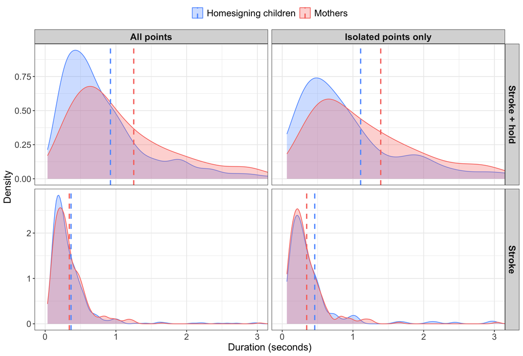

```r
ggplot(panel, aes(x = sec, fill = person_lab, colour = person_lab)) +
  geom_density(alpha = 0.3) +
  geom_vline(data = panel_means, aes(xintercept = m, colour = person_lab),
             linetype = "dashed", linewidth = 0.9) +
  facet_grid(measure ~ set, scales = "free") +
  scale_colour_manual(values = person_cols) +
  scale_fill_manual(values = person_cols) +
  coord_cartesian(xlim = c(0, 3)) +
  labs(x = "Duration (seconds)", y = "Density") +
  theme_bw() +
  theme(text = element_text(size = 15), axis.text = element_text(size = 13),
        axis.title = element_text(size = 15), legend.text = element_text(size = 14),
        legend.title = element_blank(), legend.position = "top",
        strip.text = element_text(size = 14, face = "bold"),
        legend.key.height = unit(1.2, "lines"), legend.key.width = unit(1.2, "lines"))
```

# 12 Convergence (Table S9)

```r
reported <- c(
  list("Stroke" = m_stroke, "Whole point" = m_total, "Hold" = m_hold,
       "Hold, without points with hold set to zero" = m_hold_nf,
       "Phase model, primary" = m_phase,
       "Phase model, no random slopes, one residual SD" = m_phase_simple,
       "Phase model, positive durations only" = m_phase_pos,
       "Whole point x isolation" = m_iso_total, "Stroke x isolation" = m_iso_stroke,
       "Stroke x crispness" = m_crisp_stroke, "Hold x crispness" = m_crisp_hold,
       "Per dyad, whole point" = m_dyad_total, "Per dyad, hold" = m_dyad_hold,
       "Per dyad, stroke" = m_dyad_stroke),
  setNames(alternatives, paste("Whole point,", names(alternatives))))
conv <- bind_rows(Map(convergence, reported, names(reported)))
kable(conv, digits = c(0, 0, 3, 0, 0, 0, 0), row.names = FALSE)
```

| model | N | max_rhat | bulk_ess_fixed | bulk_ess_all | tail_ess_all | divergences |
| --- | --- | --- | --- | --- | --- | --- |
| Stroke | 1117 | 1.003 | 4103 | 1838 | 2443 | 0 |
| Whole point | 1117 | 1.002 | 2570 | 1776 | 2097 | 1 |
| Hold | 1117 | 1.003 | 3366 | 1508 | 2834 | 0 |
| Hold, without points with hold set to zero | 1087 | 1.004 | 3381 | 1628 | 1745 | 0 |
| Phase model, primary | 2234 | 1.005 | 1668 | 689 | 1668 | 0 |
| Phase model, no random slopes, one residual SD | 2234 | 1.007 | 3538 | 694 | 1157 | 0 |
| Phase model, positive durations only | 2085 | 1.010 | 1067 | 507 | 1672 | 0 |
| Whole point x isolation | 1115 | 1.001 | 3484 | 1694 | 2124 | 0 |
| Stroke x isolation | 1115 | 1.002 | 4159 | 1689 | 2588 | 0 |
| Stroke x crispness | 1018 | 1.001 | 4211 | 2499 | 1911 | 0 |
| Hold x crispness | 1018 | 1.004 | 4300 | 1713 | 2801 | 0 |
| Per dyad, whole point | 1117 | 1.003 | 3591 | 1905 | 2486 | 0 |
| Per dyad, hold | 1117 | 1.002 | 3480 | 2040 | 2135 | 0 |
| Per dyad, stroke | 1117 | 1.001 | 3778 | 2250 | 3344 | 0 |
| Whole point, Wider priors: intercept Normal(-1, 2), fixed effects Normal(0, 1) | 1117 | 1.003 | 2888 | 1287 | 2231 | 0 |
| Whole point, Random-effect SDs Exponential(2) | 1117 | 1.003 | 3522 | 1901 | 2715 | 0 |
| Whole point, Added family intercept | 1117 | 1.003 | 3383 | 2029 | 2223 | 0 |
| Whole point, Added person slope by family | 1117 | 1.001 | 3396 | 2783 | 2126 | 0 |
| Whole point, Added utterance intercept | 1115 | 1.004 | 4622 | 1675 | 1103 | 0 |
| Whole point, Gamma likelihood | 1117 | 1.001 | 3132 | 1650 | 3028 | 1 |
| Whole point, Added person-by-session intercept | 1117 | 1.002 | 4692 | 1942 | 2441 | 0 |
| Whole point, Number of accompanying gestures as covariate | 1115 | 1.003 | 3526 | 1632 | 2903 | 1 |
| Whole point, Without the 30 points with hold set to zero | 1087 | 1.002 | 2909 | 1572 | 2411 | 0 |
| Whole point, Without family UCHS003 | 824 | 1.001 | 3552 | 2185 | 2120 | 1 |
| Whole point, Without family UCHS008 | 808 | 1.002 | 3461 | 1533 | 1720 | 4 |
| Whole point, Without family UCHS009 | 914 | 1.002 | 3199 | 1459 | 2378 | 0 |
| Whole point, Without family UCHS010 | 805 | 1.002 | 3343 | 1736 | 2628 | 1 |

# 13 Numbers reported in the manuscript

```r
fmt <- function(r, p_label = "P") sprintf("%.3f [%.3f, %.3f]; %s = %.3f",
                                          r$estimate, r$lower, r$upper, p_label, r$p_positive)
gm <- function(m) with(geo_means(m), sprintf("children %.2f [%.2f, %.2f]; mothers %.2f [%.2f, %.2f]",
  estimate[1], lower[1], upper[1], estimate[2], lower[2], upper[2]))
no_hold <- geo_means(m_hold_nf, b = "b_hu_personMom", int = "b_hu_Intercept", inv = plogis)
conv_text <- function(labels) with(conv[conv$model %in% labels, ],
  sprintf("max R-hat %.3f; min bulk ESS %.0f; divergences %s",
          max(max_rhat), min(bulk_ess_fixed), paste(divergences, collapse = "/")))

data.frame(
  result = c("Points: children, mothers",
             "Points with no hold",
             "Whole point: convergence",
             "Whole point: mother - child; P(mother > child)",
             "Whole point: geometric means (s)",
             "Whole point: P(mother > child) in each dyad",
             "Whole point: range over 13 alternative specifications",
             "Whole point, with other gestures",
             "Whole point, alone",
             "Stroke, hold and phase models: convergence",
             "Stroke: mother - child",
             "Stroke: geometric means (s)",
             "Stroke: posterior within +/-0.20",
             "Hold length: mother - child",
             "Hold length: geometric means (s)",
             "P(no hold): children vs. mothers",
             "Phase by person interaction"),
  value = c(sprintf("%d, %d", sum(dat$person == "Child"), sum(dat$person == "Mom")),
            sprintf("%d (%.1f%%)", sum(dat$hold_sec == 0), 100 * mean(dat$hold_sec == 0)),
            conv_text("Whole point"),
            fmt(summ(whole)),
            gm(m_total),
            paste(sprintf("%.3f", dyads$p_positive[dyads$measure == "Whole point"]), collapse = ", "),
            sprintf("%.3f to %.3f", min(table_s8$estimate[-1]), max(table_s8$estimate[-1])),
            fmt(iso[1, ]),
            fmt(iso[2, ]),
            conv_text(c("Stroke", "Hold", "Phase model, primary")),
            fmt(summ(stroke)),
            gm(m_stroke),
            sprintf("%.0f%%", 100 * share_within(stroke, 0.20)),
            fmt(summ(draws_of(m_hold, "b_personMom"))),
            gm(m_hold),
            sprintf("%.2f vs. %.2f", no_hold$estimate[1], no_hold$estimate[2]),
            fmt(summ(interaction)))) %>%
  kable()
```

| result | value |
| --- | --- |
| Points: children, mothers | 655, 462 |
| Points with no hold | 149 (13.3%) |
| Whole point: convergence | max R-hat 1.002; min bulk ESS 2570; divergences 1 |
| Whole point: mother - child; P(mother > child) | 0.291 [0.153, 0.408]; P = 0.993 |
| Whole point: geometric means (s) | children 0.67 [0.58, 0.77]; mothers 0.90 [0.77, 1.04] |
| Whole point: P(mother > child) in each dyad | 1.000, 0.999, 0.946, 1.000 |
| Whole point: range over 13 alternative specifications | 0.251 to 0.301 |
| Whole point, with other gestures | 0.217 [0.073, 0.355]; P = 0.982 |
| Whole point, alone | 0.307 [0.144, 0.466]; P = 0.993 |
| Stroke, hold and phase models: convergence | max R-hat 1.005; min bulk ESS 1668; divergences 0/0/0 |
| Stroke: mother - child | 0.054 [-0.078, 0.194]; P = 0.770 |
| Stroke: geometric means (s) | children 0.27 [0.24, 0.31]; mothers 0.29 [0.26, 0.33] |
| Stroke: posterior within +/-0.20 | 94% |
| Hold length: mother - child | 0.375 [0.100, 0.592]; P = 0.977 |
| Hold length: geometric means (s) | children 0.39 [0.31, 0.49]; mothers 0.57 [0.44, 0.71] |
| P(no hold): children vs. mothers | 0.13 vs. 0.12 |
| Phase by person interaction | 0.329 [0.012, 0.608]; P = 0.950 |